# AutoTrader Technical Assessment

2024-03-22

## Dataset

- The dataset contains information on 9753 cars.
- The only make available in the data is BMW
- With data on 58 different models
- 24 different fields were provided

## Columns

| make | area |
| --- | --- |
| model | price_position |
| body_type | feature_1 |
| fuel_type | feature_2 |
| engine_size | feature_3 |
| transmission | feature_4 |
| derivative | feature_5 |
| plate | feature_6 |
| year | feature_7 |
| mileage | feature_8 |
| price | feature_9 |
| colour | feature_10 |

## Data Exploration

### Missingness

| Column name | Number of missing values |
| --- | --- |
| engine_size | 142 |
| year | 830 |
| price_position | 1214 |

## Data Exploration

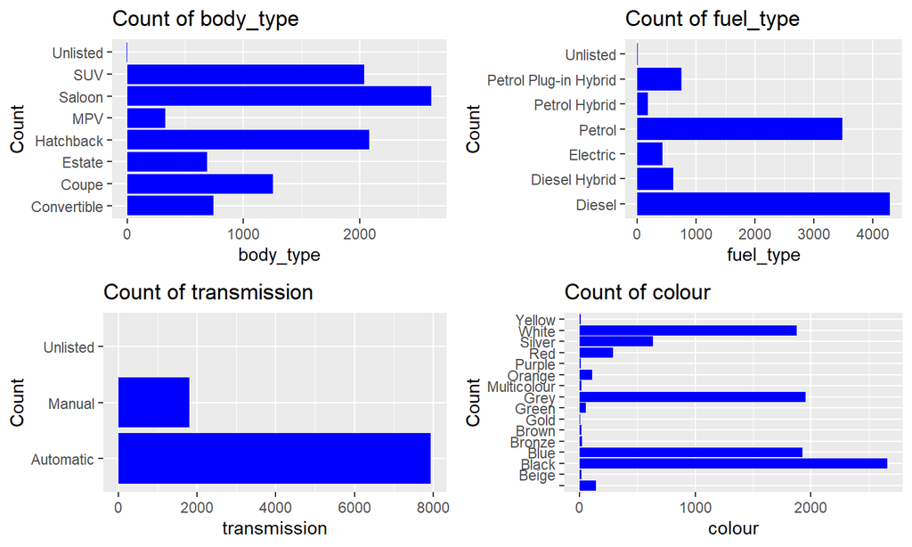

## Data Exploration

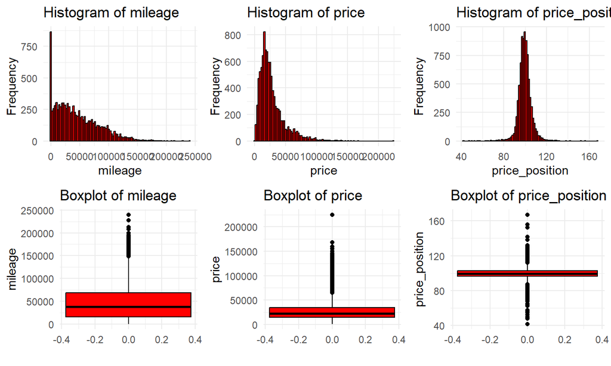

## Data Exploration

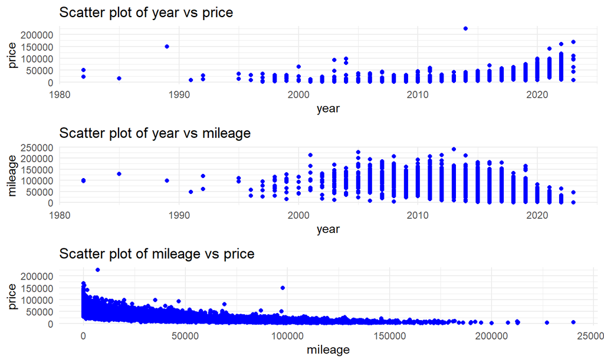

## Data Exploration

### Correlation coefficient

1. Pearson’s correlation coefficient
2. Spearman’s rho rank correlation coefficient
3. Kendall’s tau rank correlation coefficient

#### Results:

- Year and Price: 0.8307874
- Year and Mileage: -0.6344863
- Mileage and Price: -0.7801431

These result were all statistically significant.

## Data Exploration

### Regression Analysis

For every 1 unit increase in mileage, the price decreases by -0.36 [-0.37, -0.35].

### Chi-squared test

To assess the independence or association between categorical variables in the dataset:

- Fuel type and transmission
- Colour and model
- Engine size and transmission

## Feature Analysis

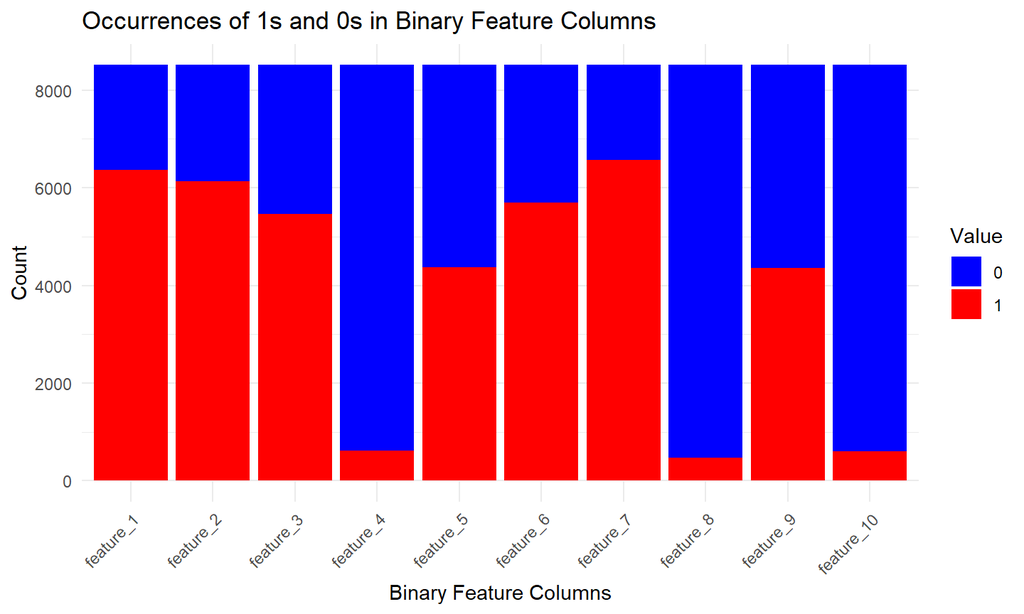

## Feature Analysis

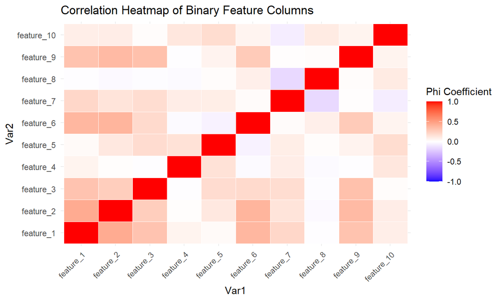

## Feature Analysis

### ANOVA

Feature 4 had a statistically significant result.

### Chi squared test

Feature 4 was the only variable with a statistically significant association with the price position, followed by Feature 7 with a slightly higher p-value.

## Feature Analysis

### Feature Importance

A random forest model was used to also confirm the importance of feature 4.

|  | %IncMSE | IncNodePurity |
| --- | --- | --- |
| feature_4 | 75.6 | 5062.4 |

## Summary

- Price position is normally distributed.
- There is a statistically significant correlation between year and price, year and mileage, mileage and price.
- There are associations between many of the categorical variables.
- Features 1 & 2, 2 & 6, 2 & 9 and 8 & 7 are correlated.
- Features 4 has an association with price position and also in predicting price position.

## Further Development

- Regression analysis
- Dimensionality reduction
- Clustering